# Final Project: Analysis on Global Migration Rates

Blinh Hoang

2023/12/14

## 1. Introduction

### Overview

This research aims to delve into the intricate nuances surrounding migration rates, particularly focusing on discerning disparities between developed and developing countries. Our investigation seeks to unravel the driving forces behind migration patterns within these distinct groups, exploring the potential influences of economic indicators such as GDP, demographic factors like Population Growth Rate, and the social support infrastructure. Crucially, we aim to ascertain whether there exists a causal relationship between these variables or if their associations are merely correlations.

### Data Sources

The dataset utilized for this research is a compilation of global demographic, economic, social, and environmental data. Drawing from reputable sources such as the United Nations, World Bank, ‘World Happiness Report,’ and ‘World Development Indicators | Databank (GDP),’ our data wrangling process is also informed by the OECD Better Life Index. This robust dataset serves as the foundation for our in-depth analysis of migration dynamics.

### Responsible Entities

The collaborative effort behind this research involves international researchers and prominent organizations such as the United Nations, World Bank, ‘World Happiness Report,’ and the OECD. The governments of the countries included in the dataset actively contribute to this collective initiative. The goal is to comprehensively understand the overarching patterns and dynamics of migration globally. Rigorous data collection and analysis form the backbone of this collaborative venture, supporting evidence-based policymaking, fostering international cooperation, and enhancing our collective knowledge to address the challenges and opportunities associated with migration on a global scale.

### Special Aspects and Considerations

The dataset encompasses a myriad of factors, spanning economic, social, and environmental dimensions, ensuring a comprehensive analysis of migration rates. However, given the vastness of the dataset, comprising over 100 countries worldwide, potential biases may arise from variations in data reporting across different regions. This may impact the accuracy of specific demographic indicators. Notably, there might be missing voices, particularly from regions with limited access to reliable demographic information. Consequently, certain variables in the dataset contain missing values (NA), prompting the need to filter specific exemplary groups of nations without NA variables to represent our data wrangling process. These considerations underline the complexity of the dataset and the conscientious approach taken in its analysis.

## 2. Data Explanation and Exploration

### a. Data Wrangling

First, I made 2 separate data sets. As solely using GDP would be insufficient, I thought of using the OECD Better Life Index would be perfect to make create 2 data set: one data set of 6 developed nations and one of 6 developing nations. Then, I created a small data set called “developed_nations” that consists of countries that are placed in the top 18 of the OECD Better Life Index. The second data set, we named “developed_nations” that has countries not in the top 40 of the OECD Better Life Index. The first group consists of the US, the UK, Switzerland, Germany, and France, and Australia and the second group consists of Guinea, Ethiopia, Tanzania, Liberia, Iran, and Uganda.

### b. Comparing Migration Rates between Developed Nations and Developing Nations

Firstly, I compare the migration rates between my two groups of nations.Examining the graph below, we can see that all of the developing countries tend to exhibit lower migration rates, while all of the developed countries show higher migration rates. There is a subtle correlation inferred from the net migration formula (Net Migration= Immigrants - Emigrants), suggesting that developing countries tend to have more emigrants, whereas more developed countries have more immigrants.

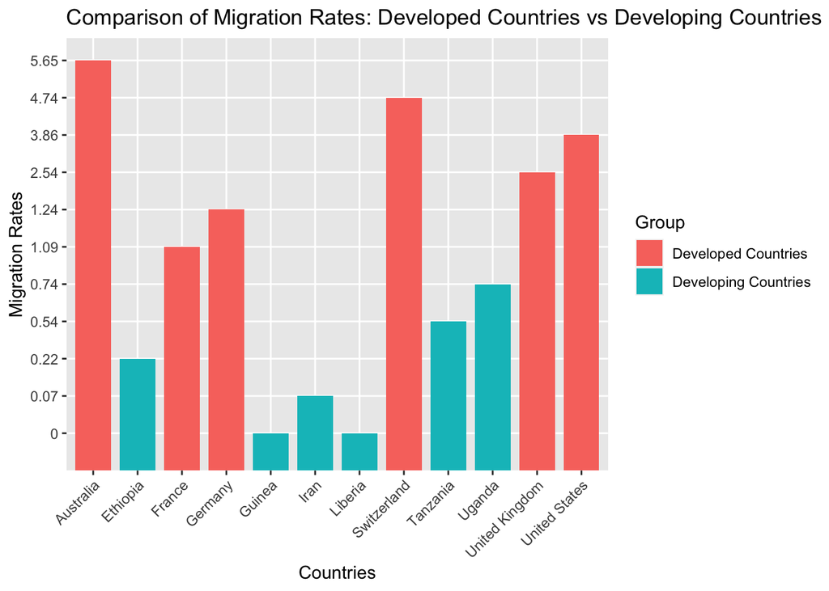

### c. Comparing Migration Rates and Population Growth Rate for Developed Nations

Next, I generate linear regression analysis for Migration.Rate and Population.Growth.Rate variables in the developed_nations dataset. As we can see from the results, the coefficient for Population.Growth.Rate is statistically significant (p-value = 0.00859, which is less than the normal significant level of 0.05), indicating that there is a significant linear relationship between Migration.Rate and Population.Growth.Rate.The positive coefficient (5.5746) suggests that as the Population.Growth.Rate increases, the Migration.Rate tends to increase as well. Moreover, the high R-squared value (0.8525) indicates that the model explains a substantial portion of the variability in Migration.Rate.To sum up, the results suggest that Population.Growth.Rate is a significant predictor of Migration.Rate in the developed_nations dataset. The linear equation for the relationship between Migration Rate (Y) and Population Growth Rate (X) based on the given regression model is Migration.Rate=−0.2510+5.5746×Population.Growth.Rate.

```
##
## Call:
## lm(formula = Migration.Rate ~ Population.Growth.Rate, data = developed_nations)
##
## Residuals:
##        1        2        3        4        5        6
## -0.06383 -1.05607  0.54333  1.03304 -0.21928 -0.23719
##
## Coefficients:
##                        Estimate Std. Error t value Pr(>|t|)
## (Intercept)             -0.2510     0.7866  -0.319  0.76561
## Population.Growth.Rate   5.5746     1.1592   4.809  0.00859 **
## ---
## Signif. codes:  0 '***' 0.001 '**' 0.01 '*' 0.05 '.' 0.1 ' ' 1
##
## Residual standard error: 0.8041 on 4 degrees of freedom
## Multiple R-squared:  0.8525, Adjusted R-squared:  0.8157
## F-statistic: 23.13 on 1 and 4 DF,  p-value: 0.008591
```

### d. Comparing Migration Rates and Population for Developing Nations

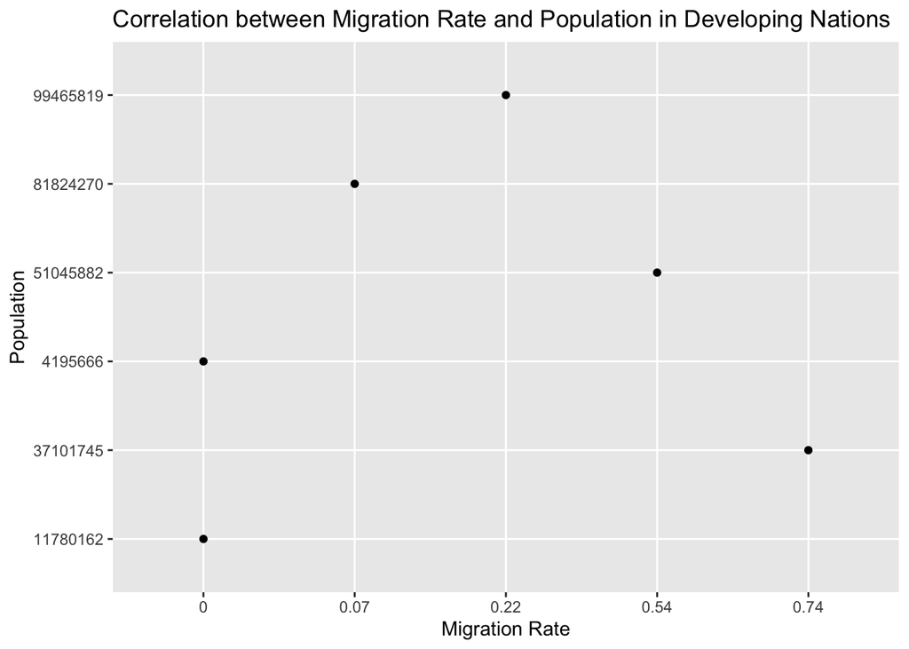